# County Education Profiles – ASAL Counties

2023-08-22

# School-aged children

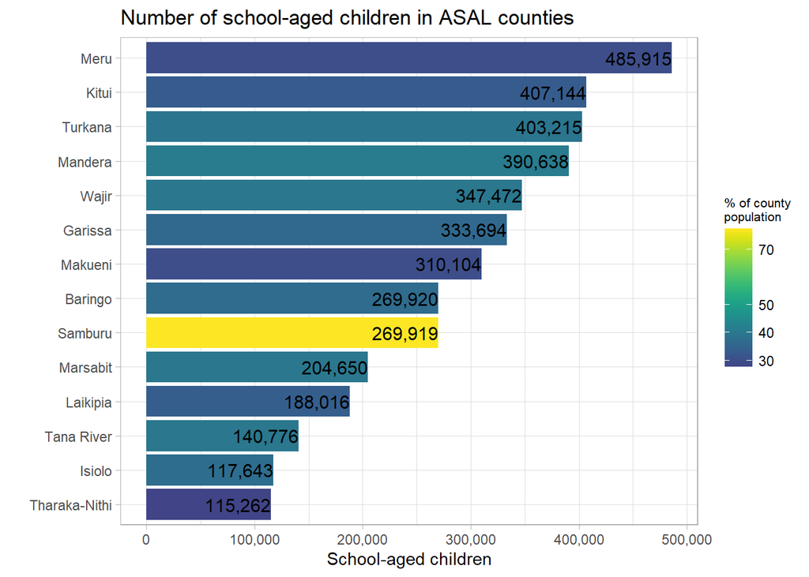

The largest numbers of school-aged children are in Meru County, though 77.5% of all persons in Samburu are of schooling age, the highest of any county.

# Enrolment

The plot below shows the net enrolment rates of both sexes at each education level. Counties have been sorted by enrolment at the secondary level.

Tharaka-Nithi, Makueniu and Meru have the highest levels of secondary enrolment – they also generally have high rates of preprimary and primary enrolment.

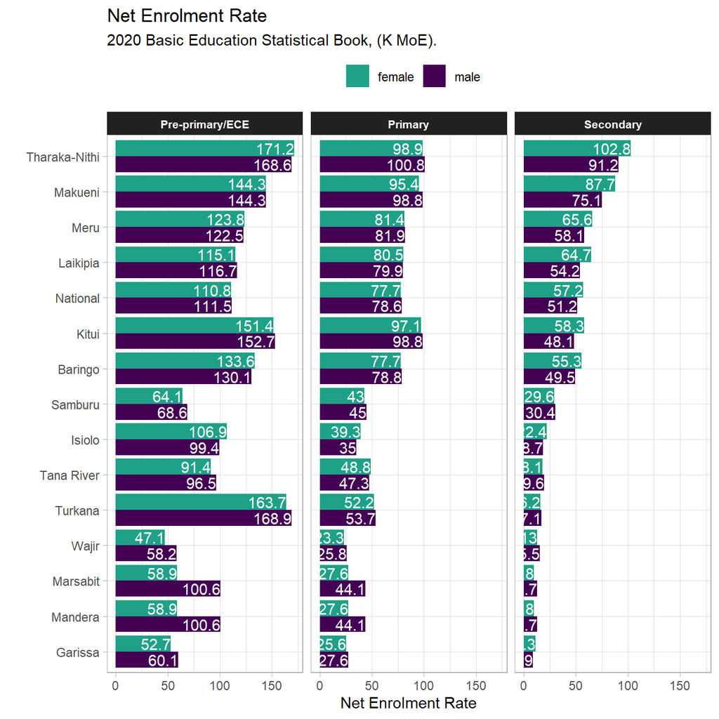

However, it is also evident that numerous counties experience significant attrition between the preprimary and secondary levels.

This phenomenon is more visible below. Turkana had the largest difference between preprimary and secondary enrolment. Male attrition is also higher than female attrition in almost all ASAL counties except Isiolo, with the difference between the sexes being the most pronounced in Marsabit and Mandera.

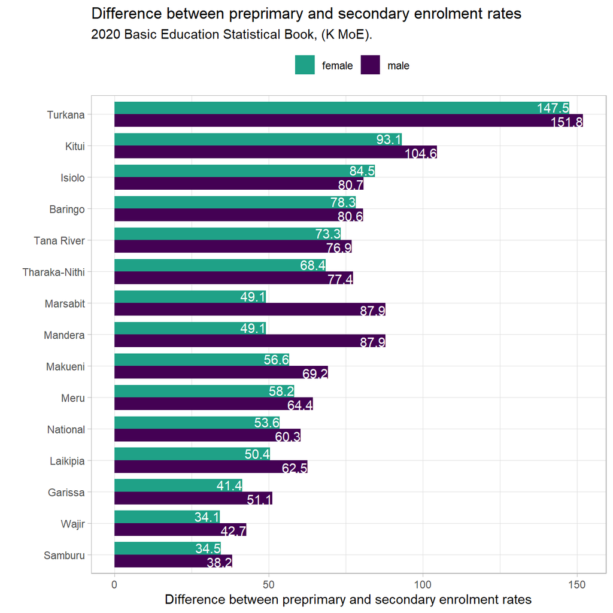

## Learner-classroom ratio

Let us explore which other factors impact enrolment rate. The supposition is that higher learner-teacher ratios and learner-classroom ratios impact enrolment.

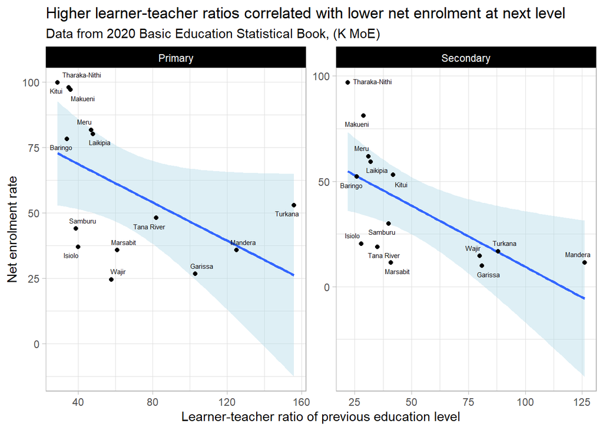

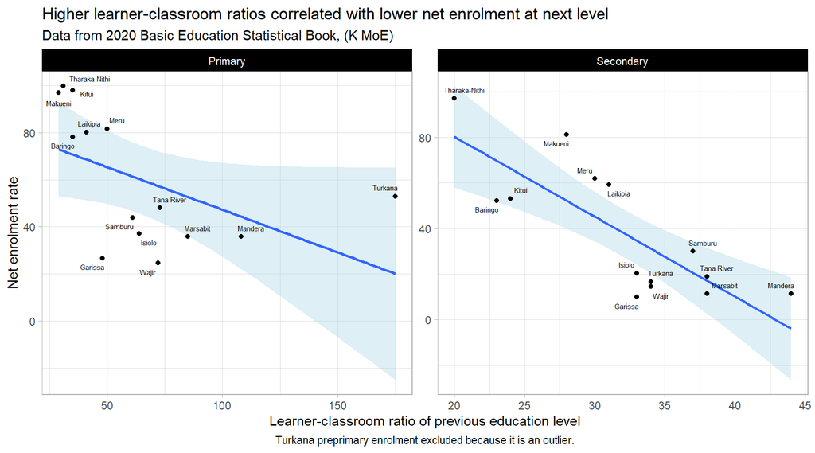

With reference to the estimate column below and given the limited data available (the digitisation of more counties and more years of data would allow for more robust testing of this hypothesis), an increase of class size at the preprimary level by 1 learner, it is estimated that the net enrolment rate would be -0.88 lower at the primary level; an increase of class sizes by 1 learner at the primary level results in a net enrolment rate that is -3.51 lower.

The same is true for the relationship between learner-teacher ratios of the previous education level and current net enrolment. Though results are only statistically significant for secondary enrolment. The data these conclusions are drawn from is limited and might not be an accurate accounting of the phenomenon. Additional data is needed.

| age_modifier | term | estimate | std.error | statistic | p.value |
| --- | --- | --- | --- | --- | --- |
| primary | learner_classroom_lag | -0.8761 | 0.2349 | -3.7291 | 0.0029 |
| secondary | learner_classroom_lag | -3.5063 | 0.7565 | -4.6347 | 0.0006 |
| primary | learner_teacher_lag | -1.0174 | 0.7727 | -1.3166 | 0.2147 |
| secondary | learner_teacher_lag | -0.5808 | 0.2084 | -2.7874 | 0.0164 |

# Protection Indicators

Below is a county-wise breakdown of protection indicators included in the county education profiles.

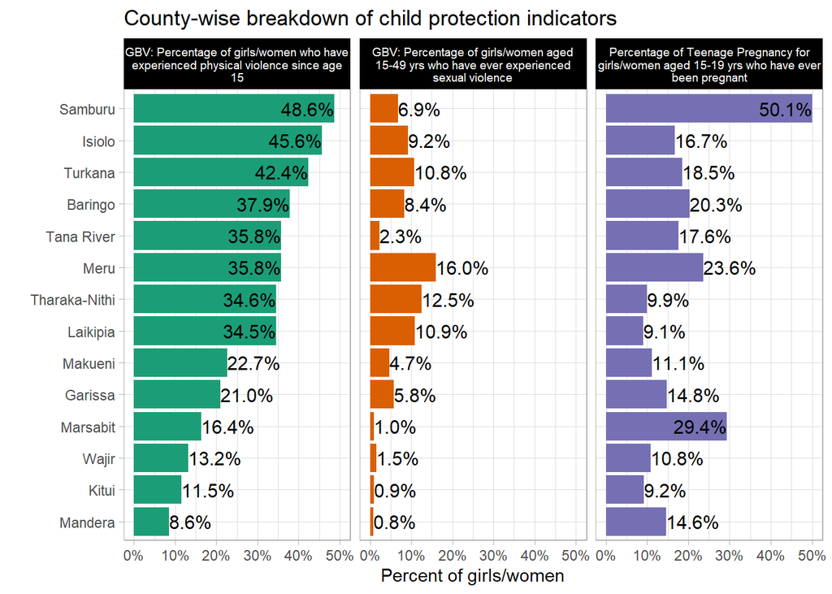

There is also wide variance in the reported rates of girls and women experiencing physical and sexual violence – some inter-county differences are very large, with 49% of girls and women having experienced physical violence in Samburu whilst in Mandera, the rate is 9%,

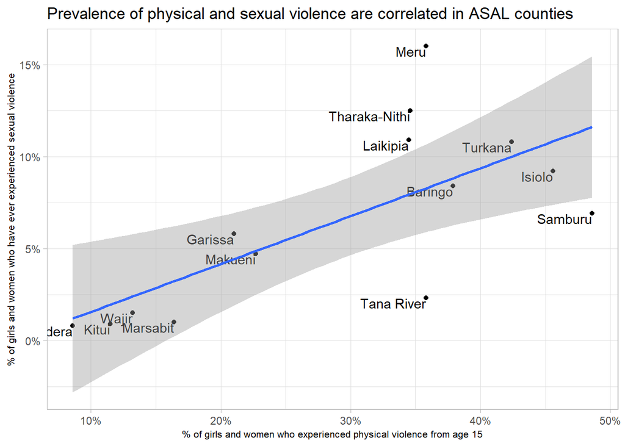

The incidence of teenage pregnancy, however, are not correlated with the rates of physical and sexual violence. And interestingly, neither are they correlated with the rates of child marriage, as recorded by a [UNICEF statistical profile](https://data.unicef.org/wp-content/uploads/country_profiles/Kenya/Child%20Marriage%20Country%20Profile_KEN.pdf). Indicating either a methodology mismatch or underreporting of child marriage or teen pregnancies and births are more likely to be reported.

Additional verification of the data is required.

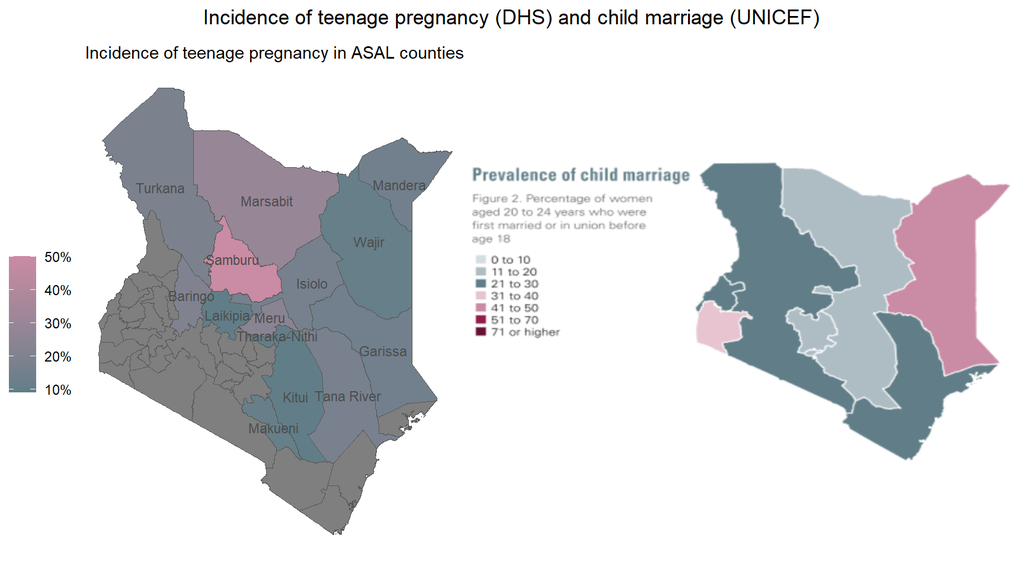

# Individual county profiles

Baringo

Garissa

Isiolo

Kitui

Laikapia

Makueni

Mandera

Marsabit

Meru

Samburu

Tana River

Tharaka-Nithi

Turkana

Wajir